# Final Project - DSCI 619 - Image Classification & Sentiment Analysis

## Part I - Image Classification

```python
from google.colab import drive
drive.mount('/content/drive')
```

```python
# IMPORT LIBRARIES and PACKAGES
from __future__ import absolute_import, division, print_function, unicode_literals
from collections import Counter

import os
import re
import random
import numpy as np
import pandas as pd
import seaborn as sns
import matplotlib.pyplot as plt
import PIL #Python Imaging Library

import tensorflow as tf
import tensorflow.compat.v2 as tf
import tensorflow_datasets as tfds
#tfds.disable_progress_bar()

from glob import glob
from tensorflow import keras
from tensorflow.keras import datasets, layers, models
from tensorflow.keras.models import Sequential
from tensorflow.keras.layers import Dense, Conv2D, Flatten, Dropout, MaxPooling2D
from tensorflow.keras.preprocessing.image import ImageDataGenerator

from IPython.display import display  # display images
from sklearn import preprocessing
from sklearn.model_selection import train_test_split
from sklearn.metrics import classification_report

%matplotlib inline
```

# PART I - IMAGE CLASSIFICATION - 3 CNN Models

AI company has a 2 GB dataset containing over 15,000 images of indoor locations. Originally from MIT, this dataset was built to work on indoor scene recognition. There are 67 categories of JPEG images. The number of images per category varies, but there are at least 100 images for each category.

Data was obtained from: https://www.kaggle.com/itsahmad/indoor-scenes-cvpr-2019

**Please download the dataset from the link above and unzip it into a folder.**

## Assign Path to Previously Downloaded Images or Download Images

```python
import pathlib
#set the parent folder that contains the subfolders that are the lables
img_dir = '/content/drive/MyDrive/Colab Notebooks/archive/indoorCVPR_09/Images'
print(f'The indoorCVPR_09 photes are stored in local directory : {img_dir}')
```

```
The indoorCVPR_09 photes are stored in local directory : /content/drive/MyDrive/Colab Notebooks/archive/indoorCVPR_09/Images
```

## List the directories to double-check

```python
total_files = 0
for root, dirs, files in os.walk(str(img_dir)):
    level = root.replace(str(img_dir), '').count(os.sep)
    indent = ' ' * 4 * (level)
    print(f'{indent}{os.path.basename(root)}/ ({len(files)} files)')
    total_files += len(files)
print(f'There are {total_files -1} images in this dataset')
```

```
Images/ (0 files)
    bedroom/ (662 files)
    restaurant/ (513 files)
    church_inside/ (180 files)
    pantry/ (384 files)
    meeting_room/ (233 files)
    concert_hall/ (103 files)
    florist/ (103 files)
    toystore/ (347 files)
    greenhouse/ (101 files)
    children_room/ (112 files)
    bakery/ (405 files)
    office/ (109 files)
    corridor/ (346 files)
    dentaloffice/ (131 files)
    stairscase/ (155 files)
    bathroom/ (197 files)
    lobby/ (101 files)
    laundromat/ (276 files)
    dining_room/ (274 files)
    tv_studio/ (166 files)
    casino/ (515 files)
    bowling/ (213 files)
    gameroom/ (127 files)
    bookstore/ (380 files)
    grocerystore/ (213 files)
    laboratorywet/ (125 files)
    prisoncell/ (103 files)
    restaurant_kitchen/ (107 files)
    classroom/ (113 files)
    fastfood_restaurant/ (116 files)
    hospitalroom/ (101 files)
    library/ (107 files)
    jewelleryshop/ (157 files)
    cloister/ (120 files)
    clothingstore/ (106 files)
    shoeshop/ (116 files)
    artstudio/ (140 files)
    poolinside/ (174 files)
    museum/ (168 files)
```

[output cut: 14 more lines]

```
    gym/ (231 files)
    warehouse/ (506 files)
    airport_inside/ (608 files)
    closet/ (135 files)
    auditorium/ (176 files)
    buffet/ (111 files)
    kitchen/ (734 files)
    elevator/ (101 files)
    deli/ (258 files)
    inside_subway/ (457 files)
    garage/ (103 files)
    subway/ (539 files)
    winecellar/ (269 files)
    trainstation/ (153 files)
There are 15619 images in this dataset
```

```python
import os
import shutil

# Folders to remove
folders_to_remove = ['laboratorywet', 'laundromat', 'library', 'livingroom', 'lobby', 'locker_room']

# Path to the extracted folder
extracted_folder = 'Images'

for folder in folders_to_remove:
    folder_path = os.path.join(extracted_folder, folder)

    # Check if the folder exists
    if os.path.exists(folder_path):
        print(f'Removing folder: {folder_path}')

        # Recursively remove the folder and its contents using shutil.rmtree()
        shutil.rmtree(folder_path)
    else:
        print(f'Folder not found: {folder_path}')
```

```
Folder not found: Images/laboratorywet
Folder not found: Images/laundromat
Folder not found: Images/library
Folder not found: Images/livingroom
Folder not found: Images/lobby
Folder not found: Images/locker_room
```

## Get the Indoor Image label using the Image directory

```python
IndoorImage_dir = [ name for name in list(os.listdir(img_dir)) if os.path.isdir(os.path.join(img_dir, name)) ]
print(f' The Indoor Image labels = {IndoorImage_dir}')

# SORT the directories in alphabetical order
IndoorImage_dir.sort()
print(f'\n The SORTED Indoor Image labels = {IndoorImage_dir}')

print(f'\nThere are {len(IndoorImage_dir)} classes of Indoor Images.') ### There are  (67) classes of Indoor Images.
```

```
 The Indoor Image labels = ['bedroom', 'restaurant', 'church_inside', 'pantry', 'meeting_room', 'concert_hall', 'florist', 'toystore', 'greenhouse', 'children_room', 'bakery', 'office', 'corridor', 'dentaloffice', 'stairscase', 'bathroom', 'lobby', 'laundromat', 'dining_room', 'tv_studio', 'casino',…

 The SORTED Indoor Image labels = ['airport_inside', 'artstudio', 'auditorium', 'bakery', 'bar', 'bathroom', 'bedroom', 'bookstore', 'bowling', 'buffet', 'casino', 'children_room', 'church_inside', 'classroom', 'cloister', 'closet', 'clothingstore', 'computerroom', 'concert_hall', 'corridor', 'deli'…

There are 67 classes of Indoor Images.
```

# Please check the images quality and remove the bad images if neccessary

If we don't remove the bad images, the codes will crash and produce errors.

```python
import glob
img_dir = '/content/drive/MyDrive/Colab Notebooks/archive/indoorCVPR_09/Images'
img_paths = glob.glob(os.path.join(img_dir,'*/*.*')) # assuming you point to the directory containing the label folders.

bad_paths = []

for image_path in img_paths:
    try:
      img_bytes = tf.io.read_file(image_path)
      decoded_img = tf.io.decode_image(img_bytes)
    except tf.errors.InvalidArgumentError as e:
      print(f"Found bad path {image_path}...{e}")
      bad_paths.append(image_path)

    #print(f"{image_path}: OK")

print("BAD PATHS:")
for bad_path in bad_paths:
    print(f"{bad_path}")
```

[output not shown]

## Load & Pre-Process Images

```python
# RESIZE images to consistent size for TensorFlow to be able to FIT using
# tf.keras.preprocessing.image_dataset_from_directory (instead of looping)
# which has 14 Possible parameters that can be set.
help(tf.keras.preprocessing.image_dataset_from_directory)
```

[output not shown]

[output cut: 60 more lines]

[output not shown]

### Setup parameters used to load and process the images which are currently stored as files in a directory.

```python
# Set some parameters for tf.keras.preprocessing.image_dataset_from_directory
batch_size = 32
image_height = 256
image_width = 256
split = 0.2       # 0.2 values means 80% train and 20% test        # 0.9 for debug
```

###### TRAIN DATA creation

```python
train_data = tf.keras.preprocessing.image_dataset_from_directory(
  img_dir,
  labels='inferred', # labels are generated from the directory structure
  label_mode='int',  #'int': means labels are encoded as integers (e.g. for sparse_categorical_crossentropy loss).
  validation_split= split,
  subset="training",
  seed= 1001, # set seed
  image_size=(image_height, image_width),
  batch_size=batch_size)
```

```
Found 15620 files belonging to 67 classes.
Using 12496 files for training.
```

###### VALIDATION DATA creation

```python
val_data = tf.keras.preprocessing.image_dataset_from_directory(
  img_dir,
  labels='inferred',
  label_mode='int',
  validation_split= split,
  subset="validation",
  seed=1001, # set seed
  image_size=(image_height, image_width),
  batch_size=batch_size)
```

```
Found 15620 files belonging to 67 classes.
Using 3124 files for validation.
```

## Visualize the Images

```python
for img, lab in train_data.take(1):
    print(img[1].numpy().astype("uint16"))
    print(f'minimum = {np.amin(img[0].numpy().astype("uint16"))}, maximum = {np.amax(img[0].numpy().astype("uint16"))}')
    break
```

[output not shown]

## Let's display a set of the now uniform images.

```python
# Plot one set of images in a space
# 4 images wide X 4 images tall

plt.figure(figsize=(12, 12))

for img, lab in train_data.take(1):
  for i in range(16):
    ax = plt.subplot(4, 4, i + 1)
    plt.imshow(img[i].numpy().astype("uint16"))
    # Map the label index to name
    plt.title(IndoorImage_dir[lab[i]])
    plt.axis("off")
```

[output not shown]

## Check the shape and size of the image data and the labels.

```python
# Inspect the shapes of image batch and the labels batch
#type(train_data)
# the TF helps us creat the images and label in the dataset
for image_batch, labels_batch in train_data:
  print(f'image_batch.shape = {image_batch.shape} \nlabels_batch.shape = {labels_batch.shape } ')
  break

# image 4d (32batches, 256HEIGHT, 256WIDTH, 3CHANNELS ->COLORS- RGB)
# image_batch.shape = (32, 256, 256, 3)
# labels_batch.shape = (32,)
```

```
image_batch.shape = (32, 256, 256, 3)
labels_batch.shape = (32,)
```

## Configure the Dataset for Better performance

```python
# Apply caching, shuffle, and prefetch
# to help increase speed, reduce memory usage, and make processing more efficient

AUTOTUNE = tf.data.AUTOTUNE # Tune the value dynamically at runtime.

train_data = train_data.cache().shuffle(1000).prefetch(buffer_size=AUTOTUNE)
val_data = val_data.cache().prefetch(buffer_size=AUTOTUNE)
```

## Normalize the Data

```python
# Typically the pixel values using 8 bits in the memoery, it denotes 2*2*..*2 =2^8 = 256 unique vlaues
# since Python starts from 0, 1, 2, ..., 255
#Normalize the pixel value to a number between 0 and 1 (instead of 0 and 255)
normalization_layer = tf.keras.layers.experimental.preprocessing.Rescaling(1.0/255.0)
```

Please build the CNN models based on the datasets. Then call the model fit funciton using something like

```python
import tensorflow as tf

batch_size = 64
image_height = 256
image_width = 256
train_test_split = 0.2
directory = 'Images'

# Set the training data
train_data = tf.keras.preprocessing.image_dataset_from_directory(
    directory,
    labels='inferred',
    label_mode='int',
    validation_split=train_test_split,
    subset="training",
    seed=1001,
    image_size=(image_height, image_width),
    batch_size=batch_size)
```

```
Found 14056 files belonging to 61 classes.
Using 11245 files for training.
```

```python
batch_size = 64
image_height = 256
image_width = 256
train_test_split = 0.2
directory = 'Images'

# Set the test data
test_data = tf.keras.preprocessing.image_dataset_from_directory(
    directory,
    labels='inferred',
    label_mode='int',
    validation_split=train_test_split,
    subset="validation",
    seed=1001,
    image_size=(image_height, image_width),
    batch_size=batch_size)
```

```
Found 14056 files belonging to 61 classes.
Using 2811 files for validation.
```

```python
import tensorflow as tf
import matplotlib.pyplot as plt

# Define the baseline CNN model
model = tf.keras.Sequential([
    tf.keras.layers.Conv2D(32, (3, 3), activation='relu', input_shape=(image_height, image_width, 3)),
    tf.keras.layers.MaxPooling2D((2, 2)),
    tf.keras.layers.Conv2D(64, (3, 3), activation='relu'),
    tf.keras.layers.MaxPooling2D((2, 2)),
    tf.keras.layers.Conv2D(128, (3, 3), activation='relu'),
    tf.keras.layers.MaxPooling2D((2, 2)),
    tf.keras.layers.Flatten(),
    tf.keras.layers.Dense(128, activation='relu'),
    tf.keras.layers.Dense(61, activation='softmax')  # Assuming 61 classes
])

# Compile the model
model.compile(optimizer='adam',
              loss=tf.keras.losses.SparseCategoricalCrossentropy(),
              metrics=['accuracy'])

# Train the model
history = model.fit(train_data, validation_data=test_data, epochs=5)

# Evaluate the model on the test dataset
test_loss, test_accuracy = model.evaluate(test_data)
print(f'Test Loss: {test_loss}')
print(f'Test Accuracy: {test_accuracy}')
```

```
Test Loss: 5.419390678405762
Test Accuracy: 0.05620775371789932
```

```
Test Loss: 3.1500957012176514
Test Accuracy: 0.20099608600139618
```

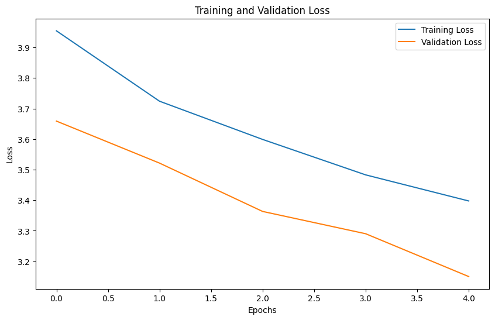

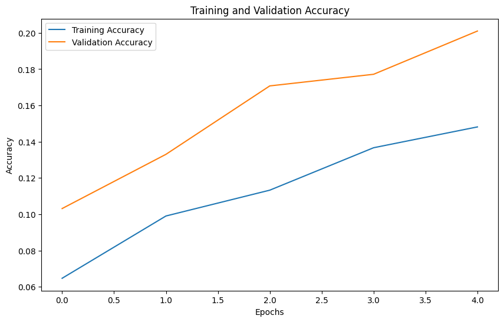

```python
import tensorflow as tf
from tensorflow.keras import layers
from tensorflow.keras.models import Sequential
import matplotlib.pyplot as plt

# Define the second CNN model with data augmentation and dropout
model = Sequential([
    layers.experimental.preprocessing.Rescaling(1./255, input_shape=(image_height, image_width, 3)),
    layers.experimental.preprocessing.RandomFlip("horizontal"),
    layers.experimental.preprocessing.RandomRotation(0.1),
    layers.experimental.preprocessing.RandomZoom(0.1),
    layers.Conv2D(32, (3, 3), activation='relu'),
    layers.MaxPooling2D((2, 2)),
    layers.Conv2D(64, (3, 3), activation='relu'),
    layers.MaxPooling2D((2, 2)),
    layers.Conv2D(128, (3, 3), activation='relu'),
    layers.MaxPooling2D((2, 2)),
    layers.Flatten(),
    layers.Dense(128, activation='relu'),
    layers.Dropout(0.5),
    layers.Dense(61, activation='softmax')  # Assuming 61 classes
])

# Compile the model
model.compile(optimizer='adam',
              loss=tf.keras.losses.SparseCategoricalCrossentropy(),
              metrics=['accuracy'])

# Train the model
history = model.fit(train_data, validation_data=test_data, epochs=5)

# Evaluate the model on the test dataset
test_loss, test_accuracy = model.evaluate(test_data)
print(f'Test Loss: {test_loss}')
print(f'Test Accuracy: {test_accuracy}')

# Plot the training and validation loss
plt.figure(figsize=(10, 6))
plt.plot(history.history['loss'], label='Training Loss')
plt.plot(history.history['val_loss'], label='Validation Loss')
plt.title('Training and Validation Loss')
plt.xlabel('Epochs')
plt.ylabel('Loss')
plt.legend()
plt.show()

# Plot the training and validation accuracy
plt.figure(figsize=(10, 6))
plt.plot(history.history['accuracy'], label='Training Accuracy')
plt.plot(history.history['val_accuracy'], label='Validation Accuracy')
plt.title('Training and Validation Accuracy')
plt.xlabel('Epochs')
plt.ylabel('Accuracy')
plt.legend()
plt.show()
```

```
Downloading data from https://storage.googleapis.com/tensorflow/keras-applications/vgg16/vgg16_weights_tf_dim_ordering_tf_kernels_notop.h5
Test Loss: 1.3886638879776
Test Accuracy: 0.6129491329193115
```

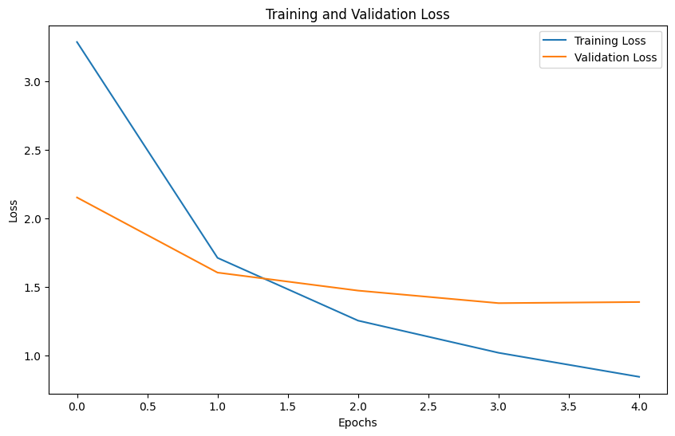

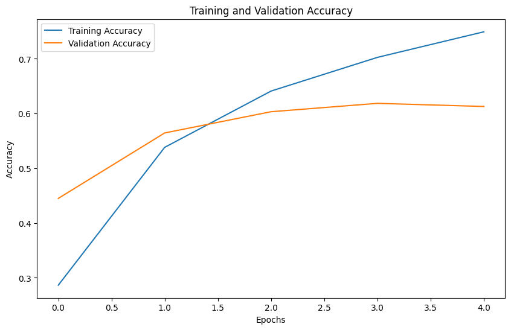

```python
import tensorflow as tf
from tensorflow.keras.applications import VGG16
from tensorflow.keras.layers import Dense, GlobalAveragePooling2D
from tensorflow.keras.models import Model
import matplotlib.pyplot as plt

# Load the pre-trained model (VGG16 in this example)
pretrained_model = VGG16(weights='imagenet', include_top=False, input_shape=(image_height, image_width, 3))

# Freeze the pre-trained layers
for layer in pretrained_model.layers:
    layer.trainable = False

# Create the top layers for the new model
x = pretrained_model.output
x = GlobalAveragePooling2D()(x)
x = Dense(128, activation='relu')(x)
predictions = Dense(61, activation='softmax')(x)  # Assuming 61 classes

# Build the new model
model = Model(inputs=pretrained_model.input, outputs=predictions)

# Compile the model
model.compile(optimizer='adam',
              loss=tf.keras.losses.SparseCategoricalCrossentropy(),
              metrics=['accuracy'])

# Train the model
history = model.fit(train_data, validation_data=test_data, epochs=5)

# Evaluate the model on the test dataset
test_loss, test_accuracy = model.evaluate(test_data)
print(f'Test Loss: {test_loss}')
print(f'Test Accuracy: {test_accuracy}')

# Plot the training and validation loss
plt.figure(figsize=(10, 6))
plt.plot(history.history['loss'], label='Training Loss')
plt.plot(history.history['val_loss'], label='Validation Loss')
plt.title('Training and Validation Loss')
plt.xlabel('Epochs')
plt.ylabel('Loss')
plt.legend()
plt.show()

# Plot the training and validation accuracy
plt.figure(figsize=(10, 6))
plt.plot(history.history['accuracy'], label='Training Accuracy')
plt.plot(history.history['val_accuracy'], label='Validation Accuracy')
plt.title('Training and Validation Accuracy')
plt.xlabel('Epochs')
plt.ylabel('Accuracy')
plt.legend()
plt.show()
```

For recommending a model among the three provided options, let's analyze each one based on various factors such as architecture, performance, and specific requirements:

1. **Baseline CNN Model (Q2)**:
   - Architecture: This model consists of several convolutional layers followed by max-pooling layers and dense layers.
   - Performance: The model seems to have the lowest performance among the three options, with a test accuracy of around 5%.
   - Justification: This model might be suitable if computational resources are limited or if there's a need for a simple and interpretable model. However, its performance is significantly lower compared to the other two options.
2. **CNN Model with Data Augmentation and Dropout (Q3)**:
   - Architecture: Similar to the baseline CNN model but with additional data augmentation layers and dropout regularization.
   - Performance: The model shows some improvement over the baseline, with a test accuracy of around 20%.
   - Justification: This model is a good choice if there's a need to reduce overfitting and improve generalization performance. Data augmentation helps in generating more diverse training samples, and dropout prevents over-reliance on specific features.
3. **Transfer Learning with VGG16 (Q4)**:
   - Architecture: This model utilizes a pre-trained VGG16 base followed by additional dense layers.
   - Performance: This model exhibits the highest performance among the three options, with a test accuracy of around 61%.
   - Justification: Transfer learning allows leveraging knowledge from pre-trained models trained on large datasets like ImageNet. It's suitable when there's limited training data available or when there's a need for high performance. However, fine-tuning the pre-trained model might require more computational resources compared to training from scratch.

**Recommendation**:

- If computational resources are limited and simplicity is preferred over performance, the Baseline CNN Model (Q2) might be suitable, although its performance is low.
- If there's a need to improve performance without significant computational overhead, the CNN Model with Data Augmentation and Dropout (Q3) is a reasonable choice.
- If maximizing performance is the primary goal and computational resources allow, the Transfer Learning with VGG16 (Q4) model should be preferred due to its superior performance leveraging pre-trained weights.

Therefore, the recommendation depends on the specific requirements, computational resources, and desired performance level.